```r
library(tidyverse)
```

```r
library(ggplot2)
```

Loading in the data and selecting the key variables

```r
df = read_csv("student-mat.csv")
df = df %>% select(c('reason', 'guardian','traveltime', 'Dalc', 'Walc', 'G1', 'G2', 'G3'))
head(df)
```

```
## # A tibble: 6 × 8
##   reason     guardian traveltime  Dalc  Walc    G1    G2    G3
##   <chr>      <chr>         <dbl> <dbl> <dbl> <dbl> <dbl> <dbl>
## 1 course     mother            2     1     1     5     6     6
## 2 course     father            1     1     1     5     5     6
## 3 other      mother            1     2     3     7     8    10
## 4 home       mother            1     1     1    15    14    15
## 5 home       father            1     1     2     6    10    10
## 6 reputation mother            1     1     2    15    15    15
```

## Reason

```r
reg = lm(Dalc~reason, data=df)
summary(reg)
```

```
##
## Call:
## lm(formula = Dalc ~ reason, data = df)
##
## Residuals:
##     Min      1Q  Median      3Q     Max
## -0.9167 -0.4759 -0.3048  0.4862  3.6952
##
## Coefficients:
##                  Estimate Std. Error t value Pr(>|t|)
## (Intercept)       1.47586    0.07303  20.208  < 2e-16 ***
## reasonhome        0.03790    0.11149   0.340  0.73408
## reasonother       0.44080    0.16376   2.692  0.00741 **
## reasonreputation -0.17110    0.11269  -1.518  0.12974
## ---
## Signif. codes:  0 '***' 0.001 '**' 0.01 '*' 0.05 '.' 0.1 ' ' 1
##
## Residual standard error: 0.8794 on 391 degrees of freedom
## Multiple R-squared:  0.03268,    Adjusted R-squared:  0.02526
## F-statistic: 4.403 on 3 and 391 DF,  p-value: 0.004622
```

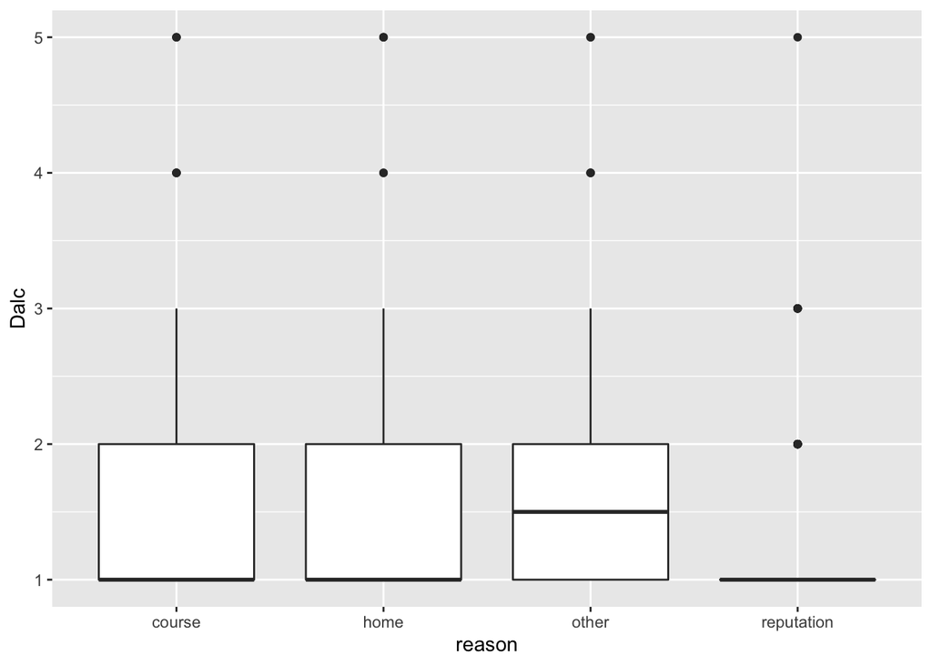

```r
ggplot(data=df, mapping=aes(x=reason, y=Dalc)) +
  geom_boxplot()
```

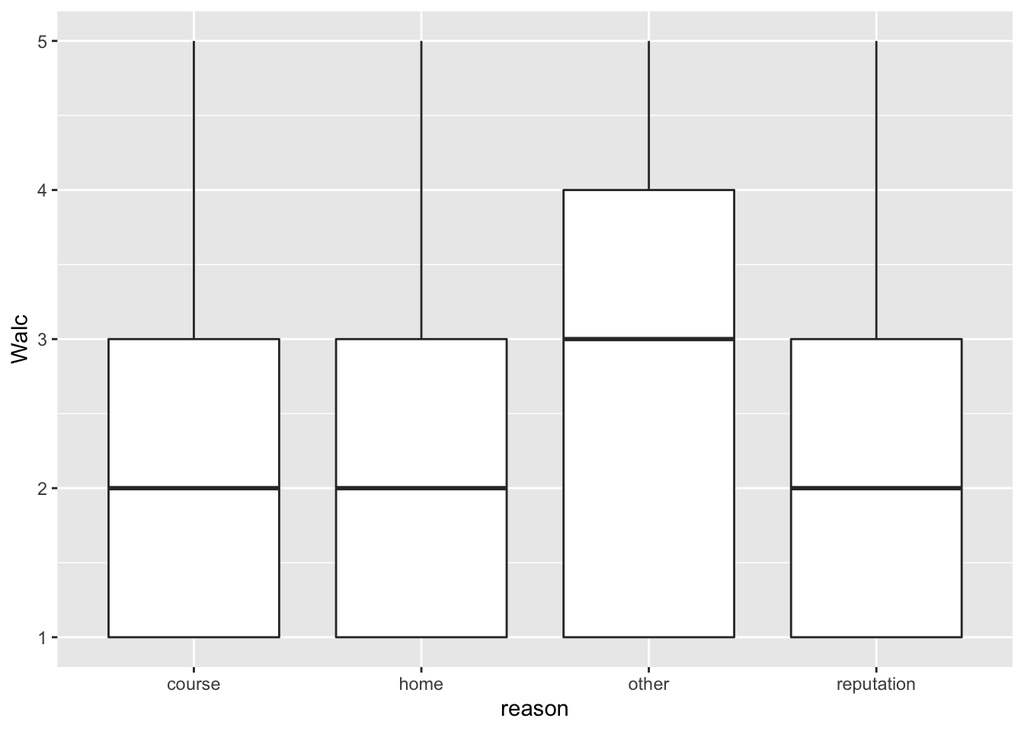

```r
ggplot(data=df, mapping=aes(x=reason, y=Walc)) +
  geom_boxplot()
```

It appears that for weekday alcohol consumption, students who chose their school due to its ‘reputation’ tend to have a lower weekday alcohol consumption. We hypothesize that this may be the case as these are the subset of students who we expect to take school more seriously which may in turn result in lower weekday alcohol consumption levels.

Students who chose ‘other’ as their reason for going to their school have a noticably higher weekend alcohol consumption on average.

```r
table(df$reason, df$Dalc)
```

```
##
##                1   2   3   4   5
##   course     101  29   8   4   3
##   home        75  20   9   2   3
##   other       18  10   3   3   2
##   reputation  82  16   6   0   1
```

```r
r = df %>% group_by(reason, Dalc) %>%
  summarize(count=n())
```

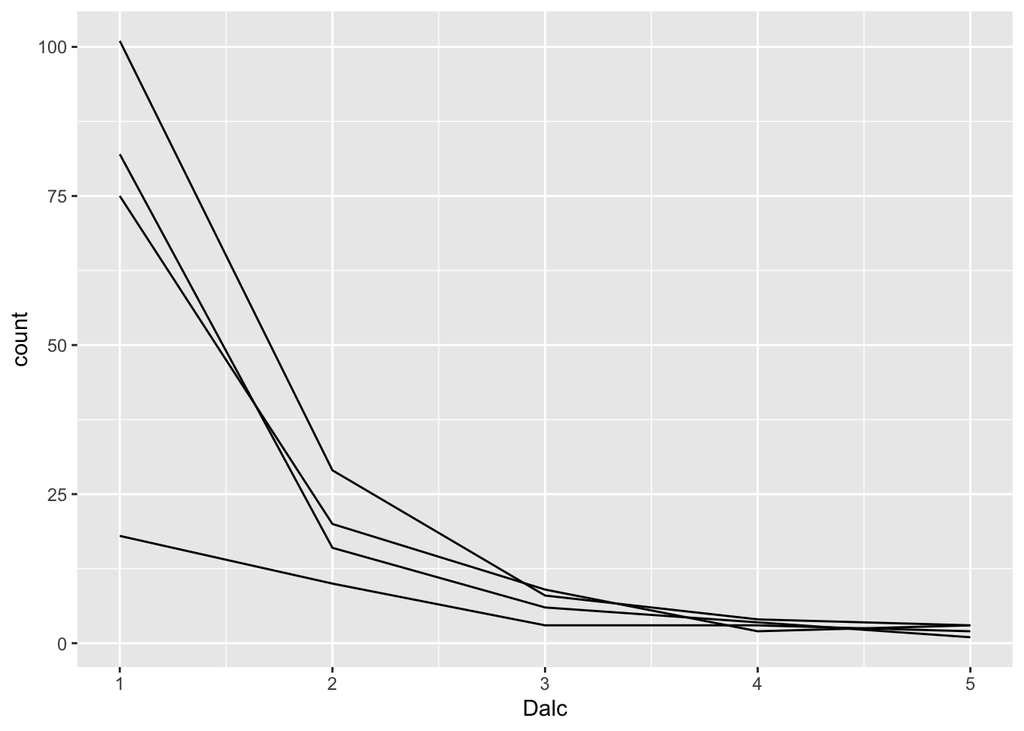

```r
ggplot(data=r, mapping=aes(x=Dalc, y=count)) + geom_line(aes(group=reason))
```

## Guardian

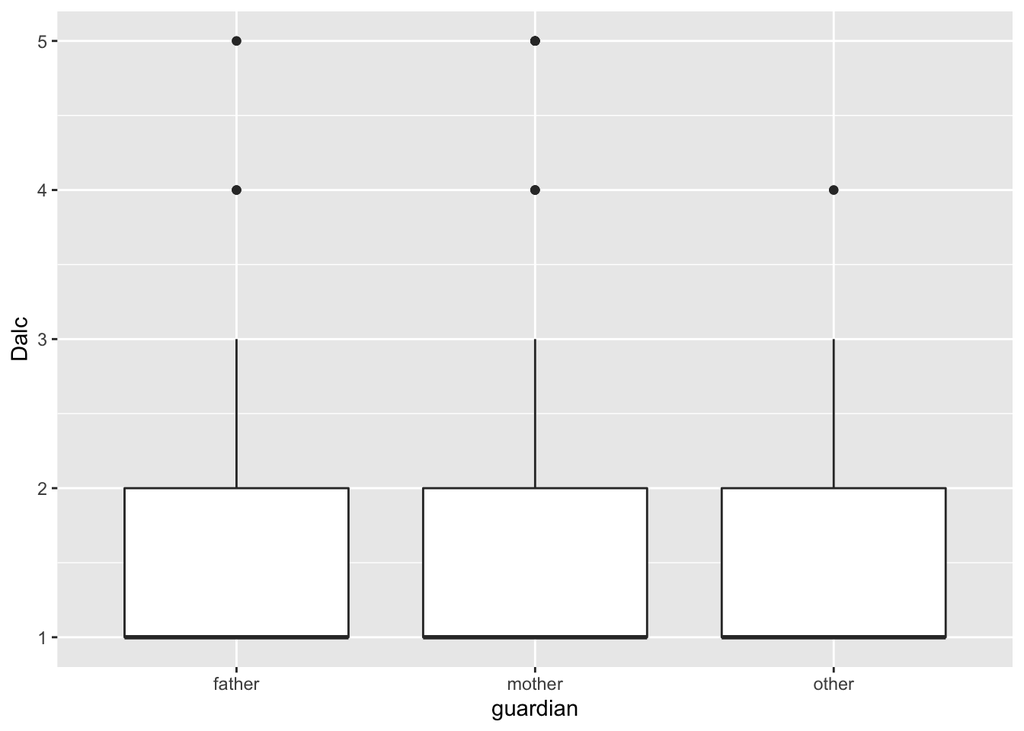

```r
ggplot(data=df, mapping=aes(x=guardian, y=Dalc)) +
  geom_boxplot()
```

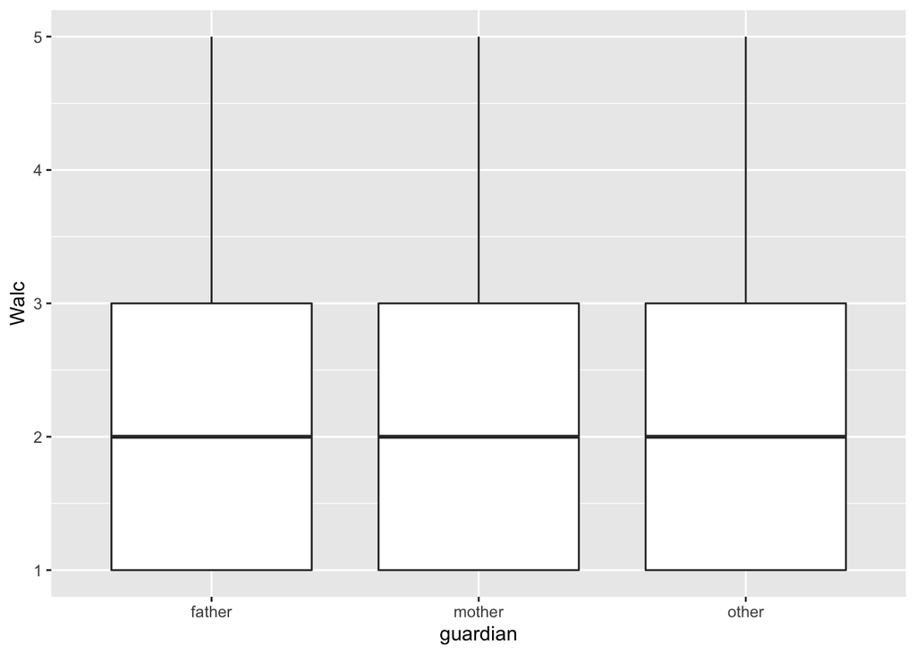

```r
ggplot(data=df, mapping=aes(x=guardian, y=Walc)) +
  geom_boxplot()
```

The three options for guardian all depict similar alcohol consumptions for both weekdays and weekends. This is likely not going to be a key indicator of a student’s alcohol consumption.

## TravelTime

THIS IS A VERY BAD AND USELESS PLOT

The plot fails since almost every combination of (x, y) -> (traveltime, dalc) exists, but the plot does not depict the frequency of these combinations.

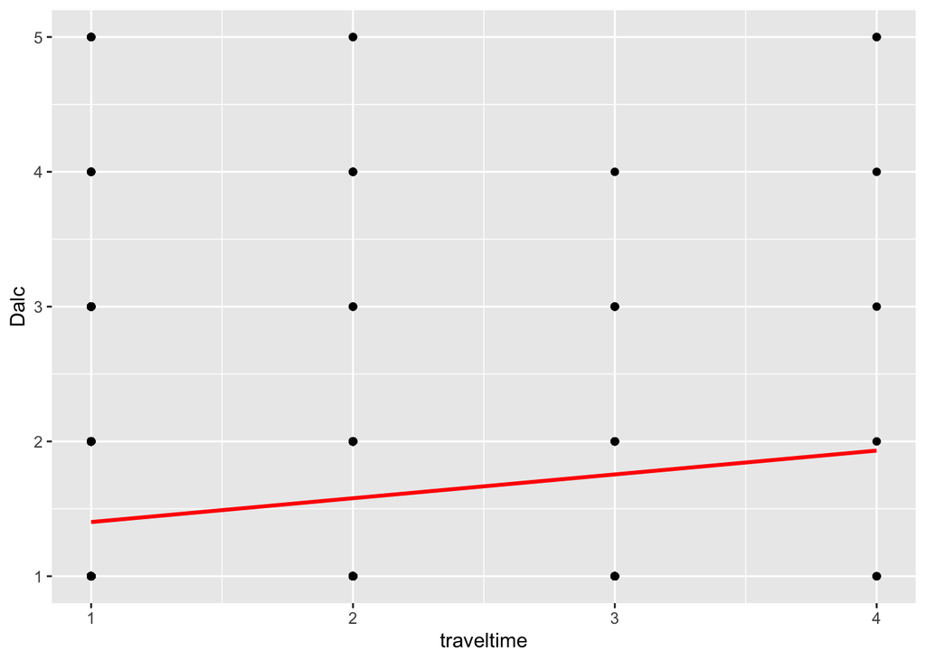

```r
ggplot(aes(x=traveltime, y=Dalc), data=df) + geom_point() + geom_smooth(method='lm', se=FALSE, color='red')
```

```r
reg = lm(Dalc ~ traveltime, data=df)
summary(reg)
```

```
##
## Call:
## lm(formula = Dalc ~ traveltime, data = df)
##
## Residuals:
##     Min      1Q  Median      3Q     Max
## -0.9318 -0.4019 -0.4019  0.4215  3.5981
##
## Coefficients:
##             Estimate Std. Error t value Pr(>|t|)
## (Intercept)   1.2252     0.1025  11.951  < 2e-16 ***
## traveltime    0.1767     0.0638   2.769  0.00589 **
## ---
## Signif. codes:  0 '***' 0.001 '**' 0.01 '*' 0.05 '.' 0.1 ' ' 1
##
## Residual standard error: 0.8833 on 393 degrees of freedom
## Multiple R-squared:  0.01913,    Adjusted R-squared:  0.01664
## F-statistic: 7.666 on 1 and 393 DF,  p-value: 0.005893
```

There is a positive correlation between travel time and weekday alcohol consumption, with a significant regression pvalue.

```r
reg = lm(Walc ~ traveltime, data=df)
summary(reg)
```

```
##
## Call:
## lm(formula = Walc ~ traveltime, data = df)
##
## Residuals:
##     Min      1Q  Median      3Q     Max
## -1.9231 -1.1802 -0.1802  0.8198  2.8198
##
## Coefficients:
##             Estimate Std. Error t value Pr(>|t|)
## (Intercept)   1.9325     0.1483  13.030  < 2e-16 ***
## traveltime    0.2476     0.0923   2.683  0.00761 **
## ---
## Signif. codes:  0 '***' 0.001 '**' 0.01 '*' 0.05 '.' 0.1 ' ' 1
##
## Residual standard error: 1.278 on 393 degrees of freedom
## Multiple R-squared:  0.01799,    Adjusted R-squared:  0.01549
## F-statistic: 7.198 on 1 and 393 DF,  p-value: 0.007605
```

Similarly, there is a positive correlation between travel time and weekend alcohol consumption, with a significant regression pvalue.

## G1 G2 G3

```r
reg = lm(Dalc ~ G2, data=df)
summary(reg)
```

```
##
## Call:
## lm(formula = Dalc ~ G2, data = df)
##
## Residuals:
##     Min      1Q  Median      3Q     Max
## -0.6437 -0.4919 -0.4463  0.4778  3.5537
##
## Coefficients:
##             Estimate Std. Error t value Pr(>|t|)
## (Intercept)  1.64369    0.13534  12.145   <2e-16 ***
## G2          -0.01518    0.01192  -1.274    0.204
## ---
## Signif. codes:  0 '***' 0.001 '**' 0.01 '*' 0.05 '.' 0.1 ' ' 1
##
## Residual standard error: 0.89 on 393 degrees of freedom
## Multiple R-squared:  0.004111,   Adjusted R-squared:  0.001577
## F-statistic: 1.622 on 1 and 393 DF,  p-value: 0.2035
```